# Введение в R

## Простые вычисления в R

```r
1234+4567
```

```
## [1] 5801
```

### Простая арифметика

```r
29-45  #вычитание
```

```
## [1] -16
```

```r
325/25 #деление
```

```
## [1] 13
```

```r
56*12  #умножение
```

```
## [1] 672
```

```r
11*11
```

```
## [1] 121
```

```r
111*111
```

```
## [1] 12321
```

```r
1111111*1111111
```

```
## [1] 1.234568e+12
```

В последнем примере можно увидеть результат в научной нотации. Такой режим устанавливается, когда в настройках указано недостаточно цифр. Автоматически R не умеет это делать. Чтобы настроить нудно количество отобрадемых цифр, требуется вызывать функцию *options*.

```r
options(digits=14)
```

Теперь можно снова повторить умножение:

```r
1111111*1111111
```

```
## [1] 1234567654321
```

## Что за цифры в квадратных скобках

```r
options(width=40)
5:32
```

```
##  [1]  5  6  7  8  9 10 11 12 13 14 15 16
## [13] 17 18 19 20 21 22 23 24 25 26 27 28
## [25] 29 30 31 32
```

## Простой генератор числовых последовательностей

### Например

```r
1:10
```

```
##  [1]  1  2  3  4  5  6  7  8  9 10
```

### Что если добавить 3?

```r
(1:10)+3
```

```
##  [1]  4  5  6  7  8  9 10 11 12 13
```

### Можно вычесть или умножить

```r
(1:10)-3
```

```
##  [1] -2 -1  0  1  2  3  4  5  6  7
```

```r
(1:10)*3
```

```
##  [1]  3  6  9 12 15 18 21 24 27 30
```

```r
(1:10)^2
```

```
##  [1]   1   4   9  16  25  36  49  64  81
## [10] 100
```

```r
(1:10)^3
```

```
##  [1]    1    8   27   64  125  216  343
##  [8]  512  729 1000
```

### Арифметика посложнее

```r
3:4
```

```
## [1] 3 4
```

Операторы сравнения по модулю (Modular arithmetic). Например, остаток от деления 31 на 7

```r
31 %% 7
```

```
## [1] 3
```

Целую часть от деления можно получить при помощи странного оператора

```r
31 %/% 7
```

```
## [1] 4
```

```r
7*4 + 3 #проверка
```

```
## [1] 31
```

## Графика и визуализация

```r
x <-c(4, 1, 8, 9)
y <-c(6, 2, 4, 3)
```

*Стрелка оператор присваивания, **c()** функция.*

Теперь можно нарисовать наши упорядоченные пары

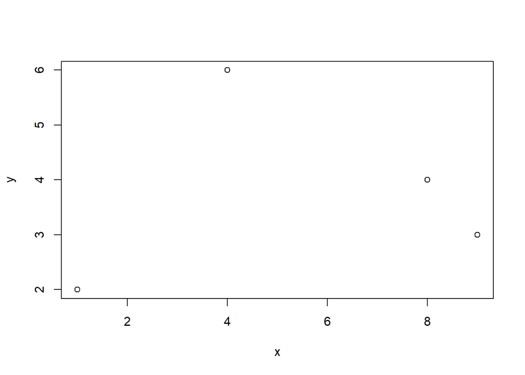

```r
plot(x, y)
```

Можно соединить точки при помощи функции *lines*

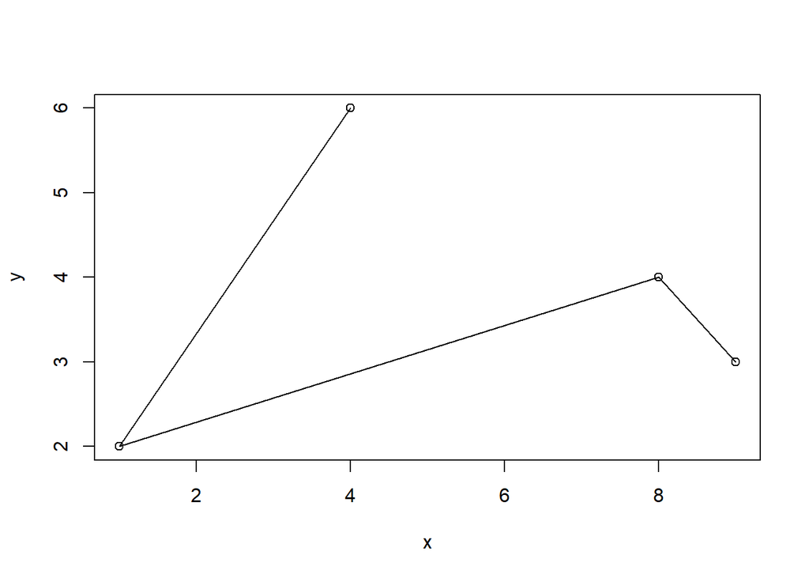

```r
plot(x,y);
lines(x, y)
```

Можно визулизировать функции

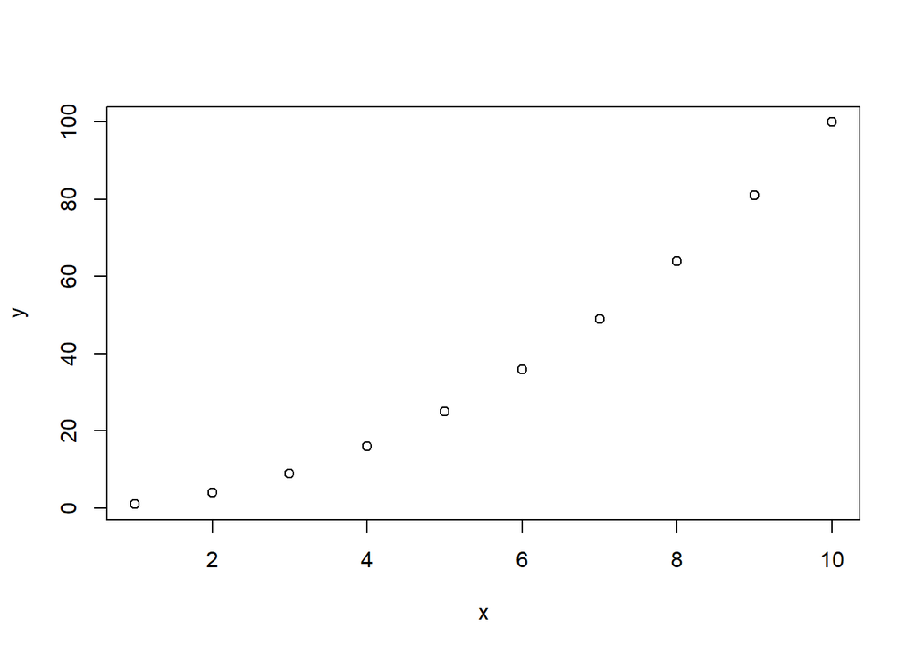

```r
x <- 1:10; y <- x^2;
plot(x,y)
```

Соединим точки

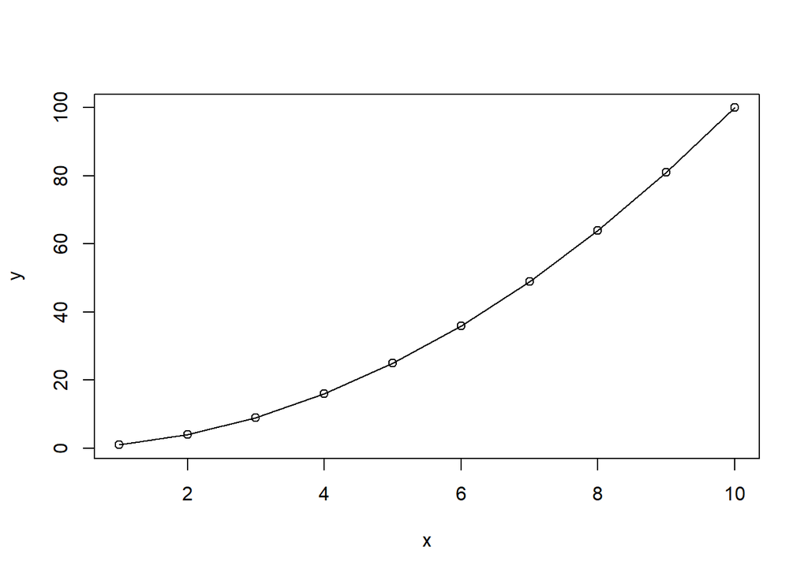

```r
plot(x,y);
lines(x,y)
```

### Столбчатые графики и круговые диаграммы (barchart)

Чтобы успешно освоить данный предмет, необходимо затратить время на следующие 4 вида деятельности: 15% повторение основ статистики, 10% повторение основ математики, 30% программирование и 45% попытки понять какой во всём этом смысл и как оно устроено.

#### Отобразим это в виде диаграммы

Для начала инициализируем данные

```r
learn <-c("stats" = 15, "math"= 10,"programming" = 30, "attempts" = 45)
```

Функция *pie()* позволяет отобразить такие данные в виде крговой диаграммы.

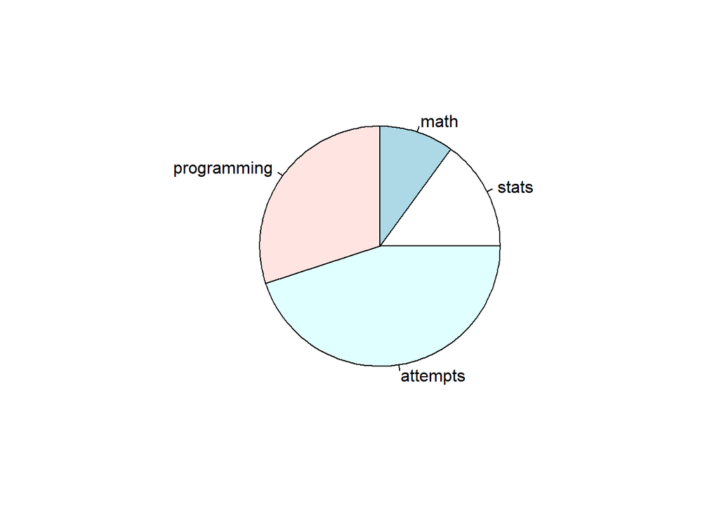

```r
pie(learn)
```

И в виде столбчатой диаграммы

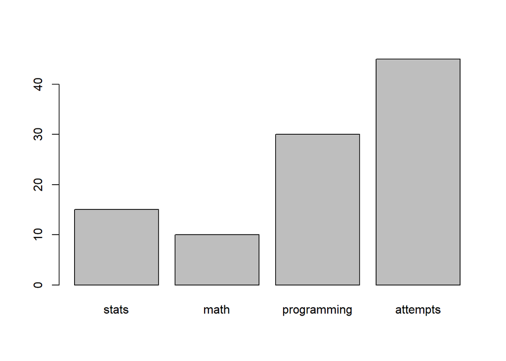

```r
barplot(learn)
```

### Гистограммы и моделирование

Функция *hist()* используется для рисования гистограмм, для моделирования ставок будем использовать функцию *rnorm()*

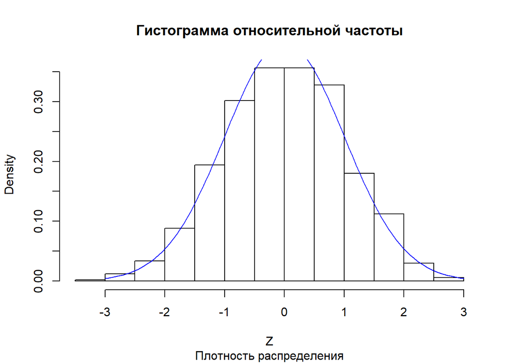

```r
Z <- rnorm(1000)# 1000 standard normal random variates
hist(Z, prob = TRUE, main = "Гистограмма относительной частоты",
sub = "Плотность распределения")
curve(dnorm(x), from = -3, to = 3, add = TRUE, col = "blue")
```